# Red Wine Quality Exploration by Tao Zhou

One thing I want to mention on the start is that this .rmd file is able be “knit”ed to HTML successfully. But I find that very rarely the processing is halted. When such an occasion happens, just “knit” it again.

Before the exploration, we have to load the data. The data set I chose is Red Wine Quality. I chose this data set mainly because its size is suitable for my laptop, which does not require a very high performance. The other reason is that I’m interested in which features determine the quality of red wine. It’s what I’m going to explore in this project. By finding the features that affect the quality of red wine, I may be able to build a math model to predict the quality of one sample of red wine.

# Univariate Plots Section

```
## [1] 1599   13
```

```
##  [1] "X"                    "fixed.acidity"        "volatile.acidity"
##  [4] "citric.acid"          "residual.sugar"       "chlorides"
##  [7] "free.sulfur.dioxide"  "total.sulfur.dioxide" "density"
## [10] "pH"                   "sulphates"            "alcohol"
## [13] "quality"
```

“X” is just the entry order not one feature. So I would like to delete this column and then see the structure of data frame.

```
## 'data.frame':    1599 obs. of  12 variables:
##  $ fixed.acidity       : num  7.4 7.8 7.8 11.2 7.4 7.4 7.9 7.3 7.8 7.5 ...
##  $ volatile.acidity    : num  0.7 0.88 0.76 0.28 0.7 0.66 0.6 0.65 0.58 0.5 ...
##  $ citric.acid         : num  0 0 0.04 0.56 0 0 0.06 0 0.02 0.36 ...
##  $ residual.sugar      : num  1.9 2.6 2.3 1.9 1.9 1.8 1.6 1.2 2 6.1 ...
##  $ chlorides           : num  0.076 0.098 0.092 0.075 0.076 0.075 0.069 0.065 0.073 0.071 ...
##  $ free.sulfur.dioxide : num  11 25 15 17 11 13 15 15 9 17 ...
##  $ total.sulfur.dioxide: num  34 67 54 60 34 40 59 21 18 102 ...
##  $ density             : num  0.998 0.997 0.997 0.998 0.998 ...
##  $ pH                  : num  3.51 3.2 3.26 3.16 3.51 3.51 3.3 3.39 3.36 3.35 ...
##  $ sulphates           : num  0.56 0.68 0.65 0.58 0.56 0.56 0.46 0.47 0.57 0.8 ...
##  $ alcohol             : num  9.4 9.8 9.8 9.8 9.4 9.4 9.4 10 9.5 10.5 ...
##  $ quality             : int  5 5 5 6 5 5 5 7 7 5 ...
```

```
##  fixed.acidity   volatile.acidity  citric.acid    residual.sugar
##  Min.   : 4.60   Min.   :0.1200   Min.   :0.000   Min.   : 0.900
##  1st Qu.: 7.10   1st Qu.:0.3900   1st Qu.:0.090   1st Qu.: 1.900
##  Median : 7.90   Median :0.5200   Median :0.260   Median : 2.200
##  Mean   : 8.32   Mean   :0.5278   Mean   :0.271   Mean   : 2.539
##  3rd Qu.: 9.20   3rd Qu.:0.6400   3rd Qu.:0.420   3rd Qu.: 2.600
##  Max.   :15.90   Max.   :1.5800   Max.   :1.000   Max.   :15.500
##    chlorides       free.sulfur.dioxide total.sulfur.dioxide
##  Min.   :0.01200   Min.   : 1.00       Min.   :  6.00
##  1st Qu.:0.07000   1st Qu.: 7.00       1st Qu.: 22.00
##  Median :0.07900   Median :14.00       Median : 38.00
##  Mean   :0.08747   Mean   :15.87       Mean   : 46.47
##  3rd Qu.:0.09000   3rd Qu.:21.00       3rd Qu.: 62.00
##  Max.   :0.61100   Max.   :72.00       Max.   :289.00
##     density             pH          sulphates         alcohol
##  Min.   :0.9901   Min.   :2.740   Min.   :0.3300   Min.   : 8.40
##  1st Qu.:0.9956   1st Qu.:3.210   1st Qu.:0.5500   1st Qu.: 9.50
##  Median :0.9968   Median :3.310   Median :0.6200   Median :10.20
##  Mean   :0.9967   Mean   :3.311   Mean   :0.6581   Mean   :10.42
##  3rd Qu.:0.9978   3rd Qu.:3.400   3rd Qu.:0.7300   3rd Qu.:11.10
##  Max.   :1.0037   Max.   :4.010   Max.   :2.0000   Max.   :14.90
##     quality
##  Min.   :3.000
##  1st Qu.:5.000
##  Median :6.000
##  Mean   :5.636
##  3rd Qu.:6.000
##  Max.   :8.000
```

Let’s have a look at the distritution of red wine quality. Later I want to explore the distribution of features that may affect the quality of wine.

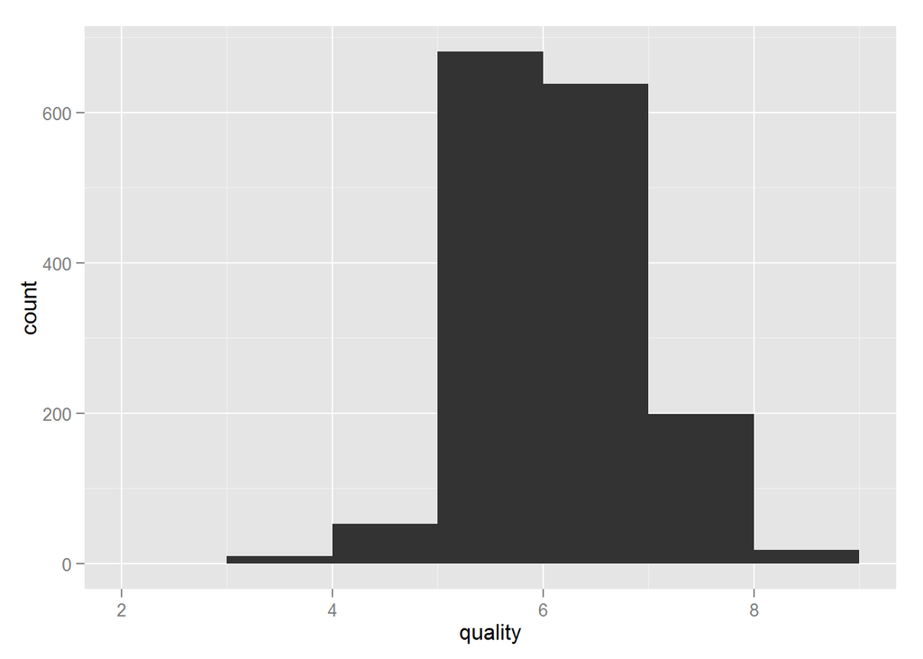

The quality distribution is similar to a normal distribution. There is no gap or long tail. But what is interesting is that there is no wine of extreme quality. All enties have a quality value between 3 and 8, and most are 5 or 6. (0 is the poorest quality and 10 is the highest.)

Now let’s check the fixed acidity distribution.

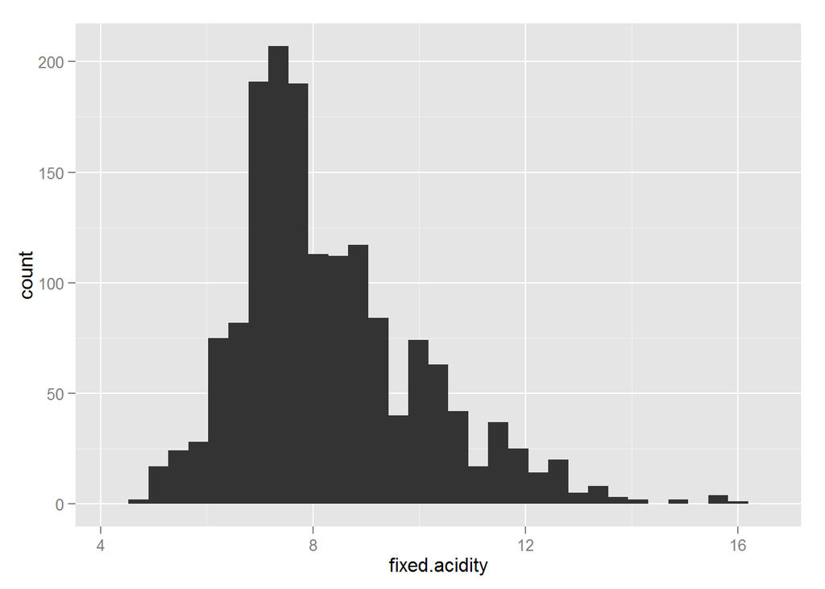

Most of the fixed acidity values are located between 7.0 and 9.0. The distribution have a tail. But since it’s very small, I’m not going to cut it.

Check the distribution of valatile acidity

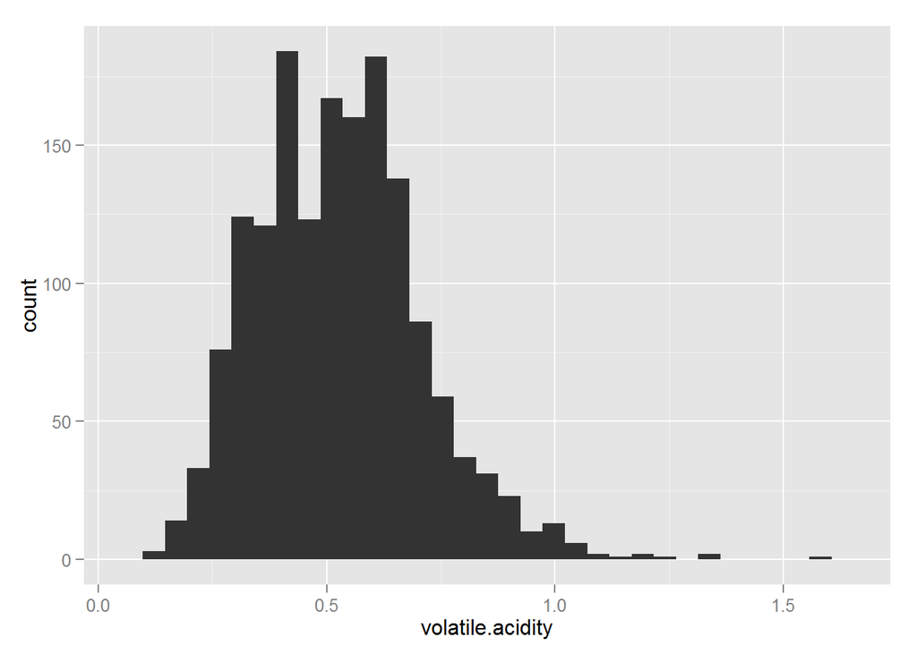

The values of vaolatile acidity are mainly between 0.0 and 1.0. There are a small number of points larger than 1.1. They are outliers. I’m going to cut the outliers larger than 1.1 in the next code chunk.

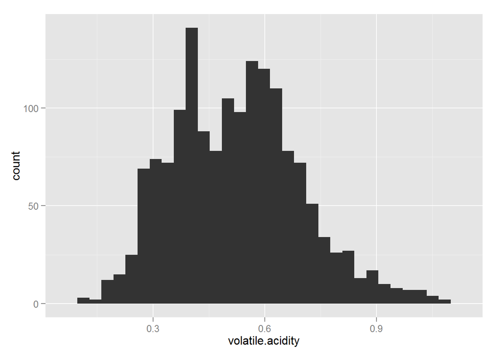

After cutting tail, the new distribuion of volatile acidity is above. We see there are two peaks, one is at about 0.4 ant the other 0.6.

Check the distribution of citric acid.

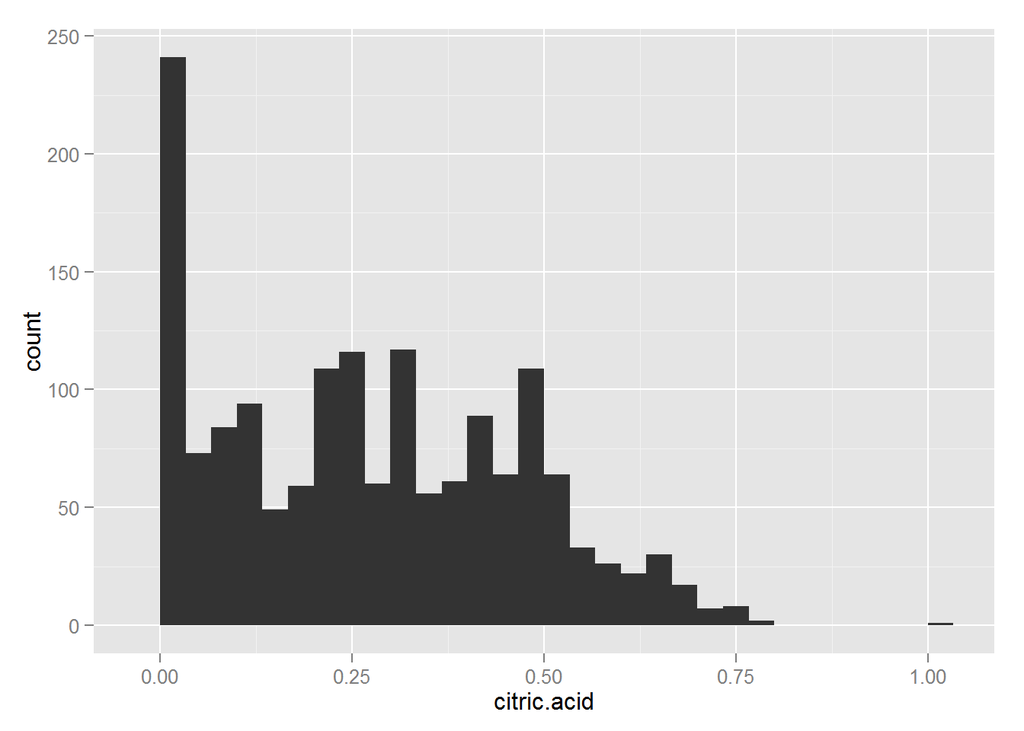

The distribution of citric acid is very different from normal distribution or skew distribution. We can see there are a lot of samples having citric acid at zero. That means there is no citric acid in those samples. There is also outliers larger than 0.9. I will cut it.

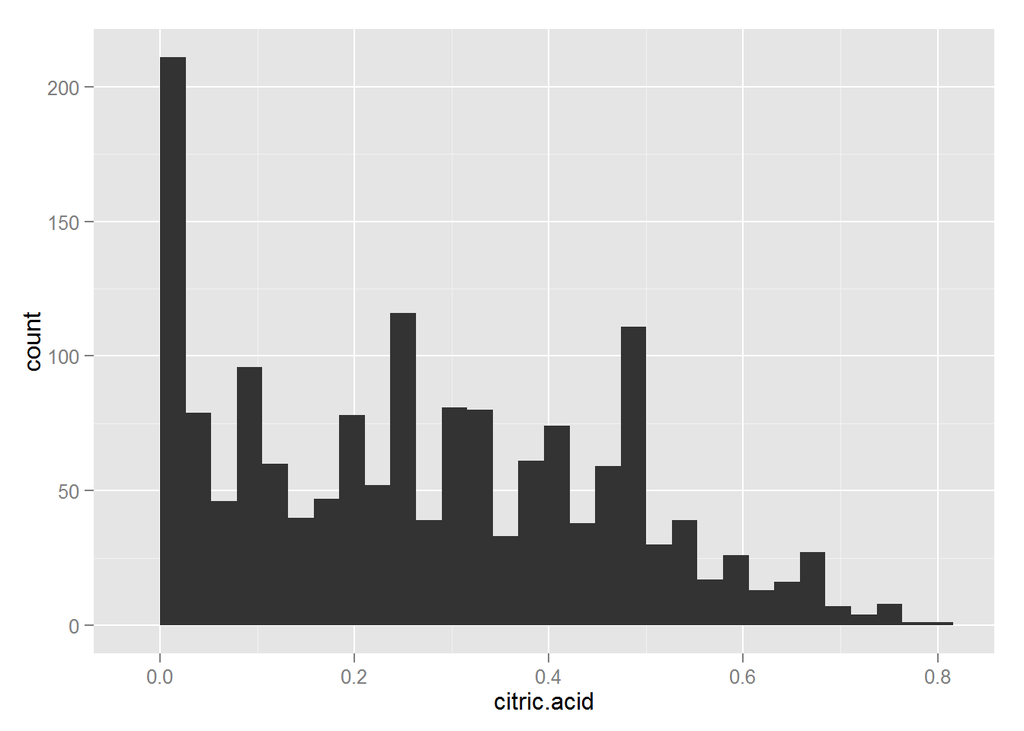

There are a lot of samples which have 0 citric acid. And from 0.02 to 0.5, the distribution is pretty random. Then from 0.5 to 0.8, the distribution is decreasing.

Check the distribution of residual sugar.

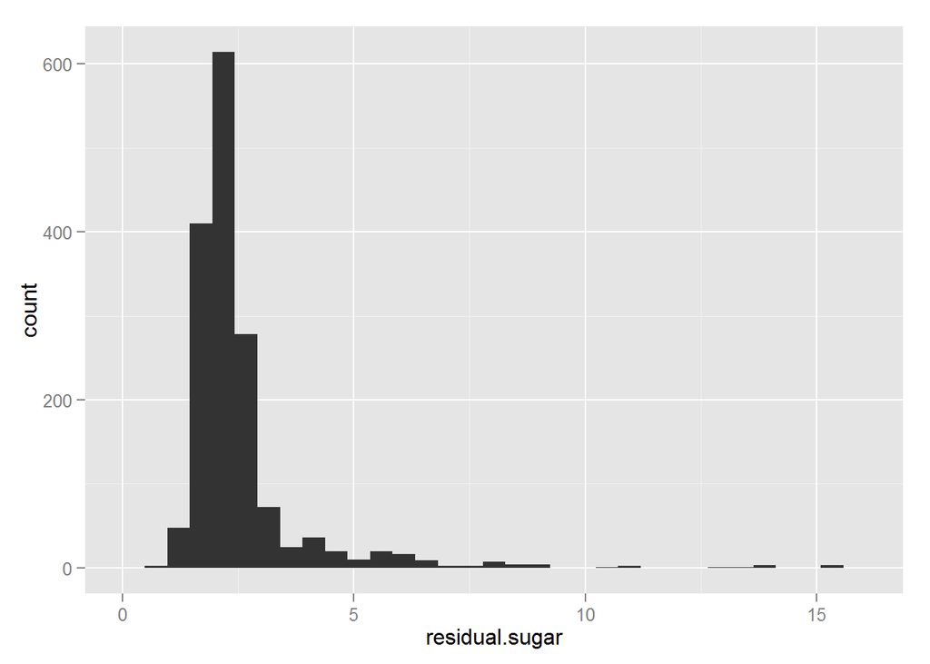

The distribution of residual sugar has a long tail. Most samples have a value of residual sugar between 1 and 5. I will cut the outliers with a value larger than 8.

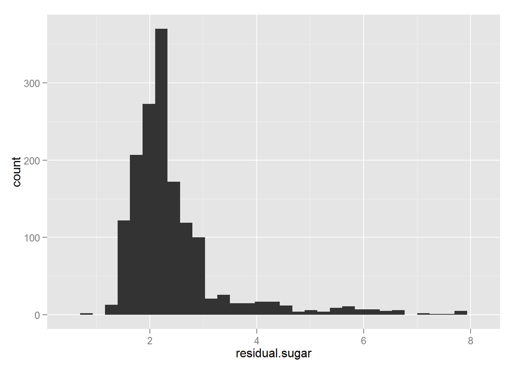

It’s interesting to see that after cutting tails larger than 8, the new distribution still have a very long tail. Next, I’m going to cut the values larger than 4.

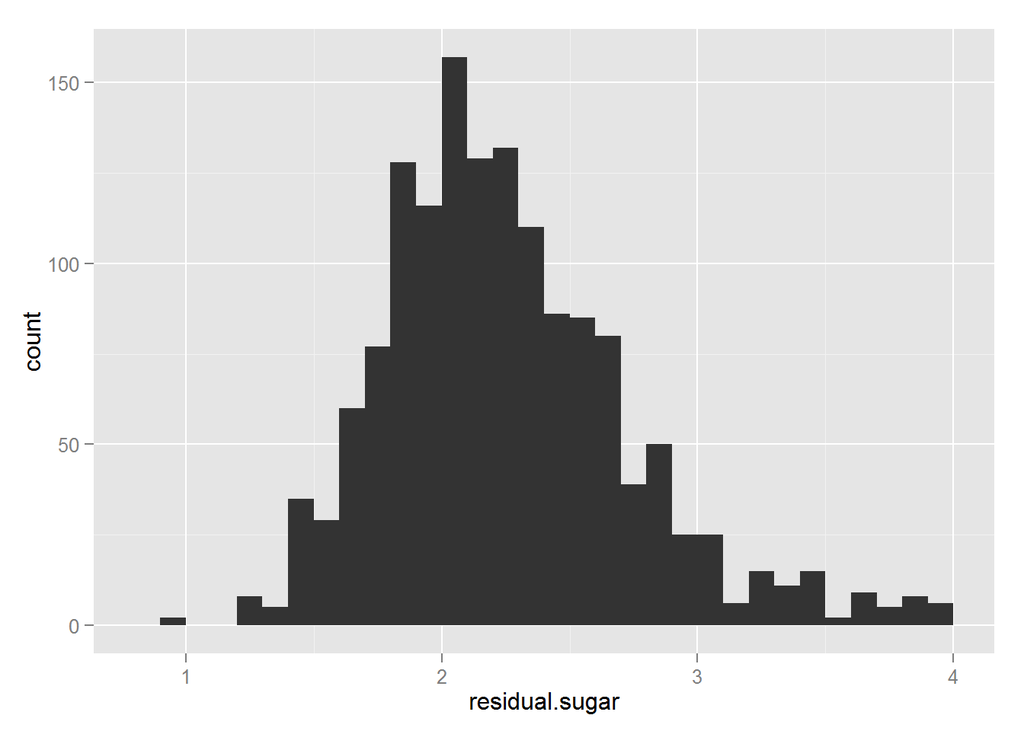

Now the distribution is very simlilar to normal distribution.

Check the distribution of chlorides.

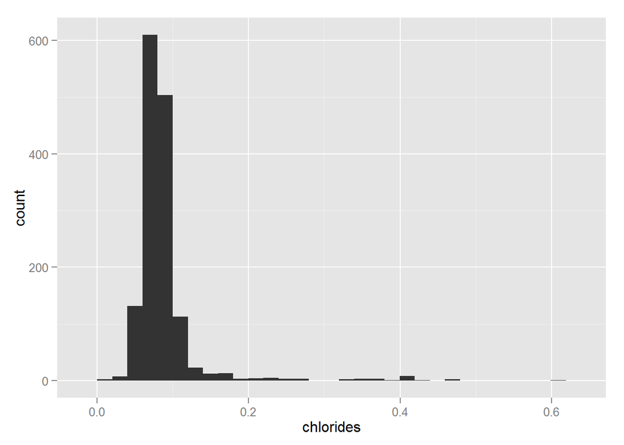

If we compare the distribution of residual sugar before cutting tail and that of chlorides, we can see the distribution shapes are very similar. That is interesting. I will cut the outliers with a value larger than 0.3.

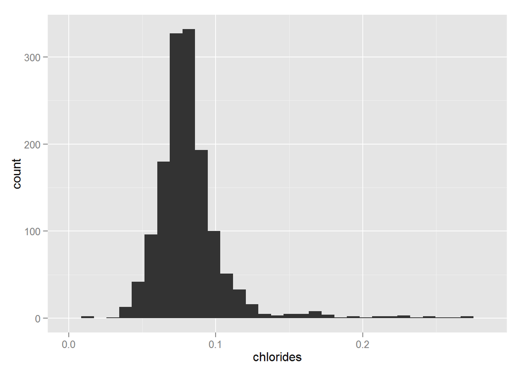

Continue cutting values larger than 0.14 or smaller than 0.02.

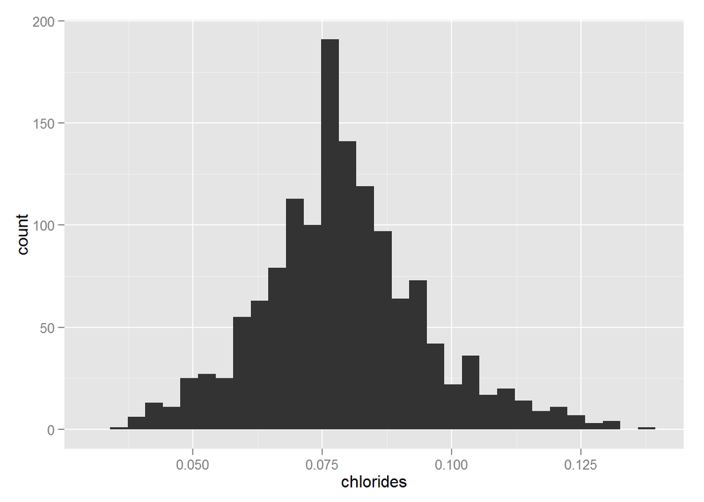

The new distribution is very similar to normal disitribution. Most points locate between 0.050 and 0.100.

Check the distribution of free sulfur dioxide.

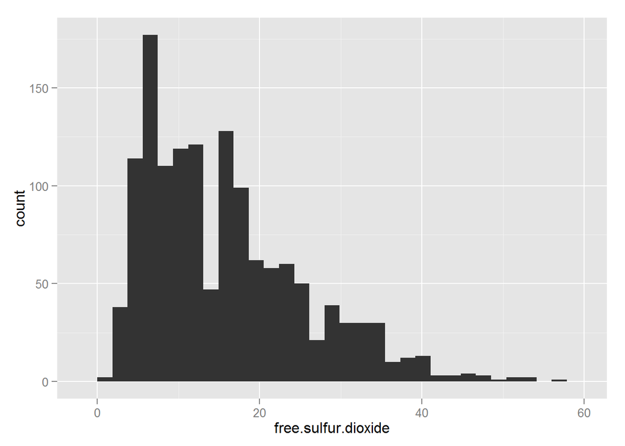

The distribution is very similar to skew distribution. Most of the values are between 0 and 20.

Check the distribution of total sulfur dioxide.

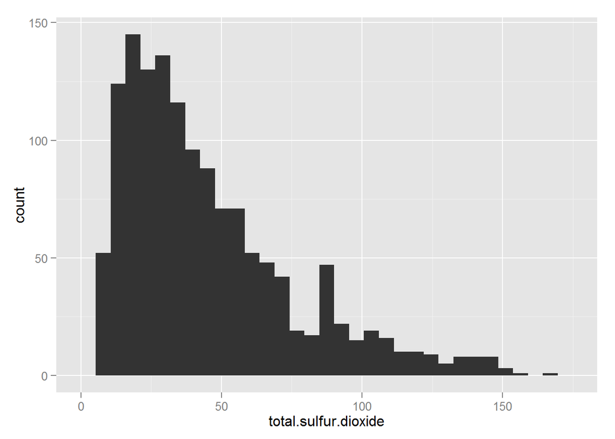

The distribution is like a skew distribution. Most of the values are between 0 and 100.

Check the distribution of density.

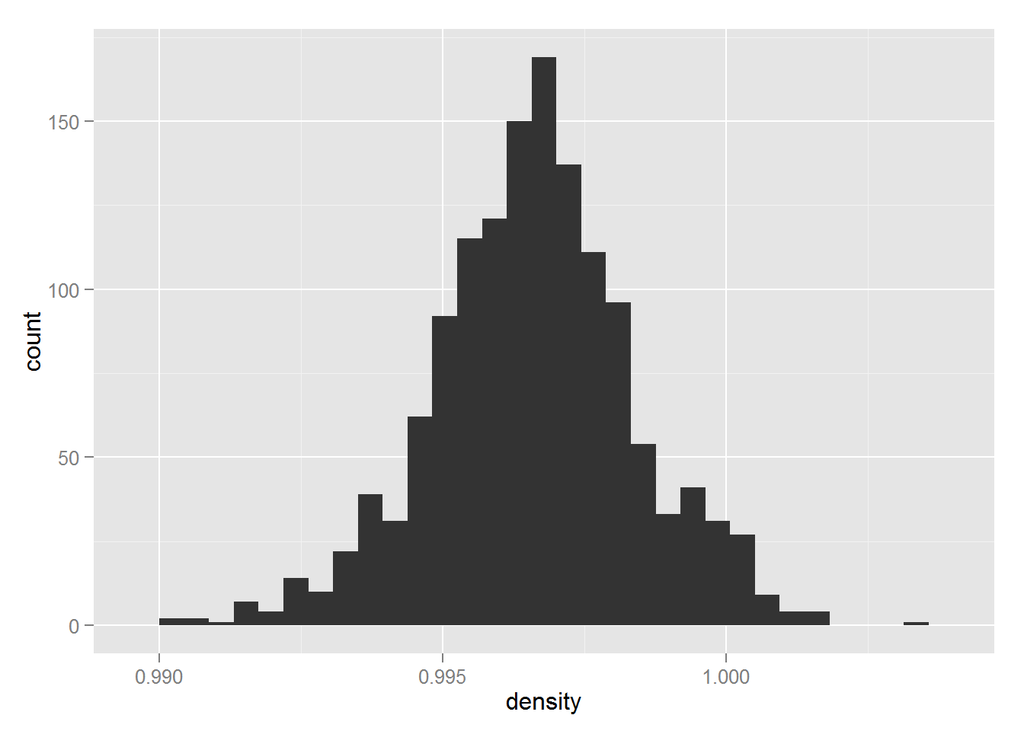

This distribution is a perfect normal distribution. It’s interesting to see most part of density is below 1.0, which is the density of pure water. I guess that’s because there is alcohol in wine and aclcohol density is smaller than water.

Check the distribution of pH.

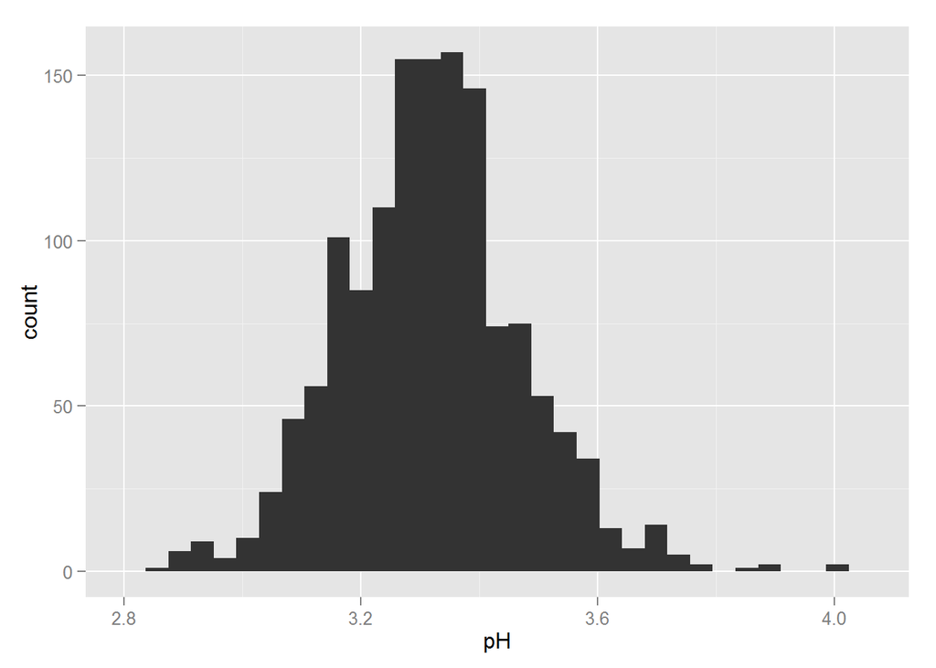

Most pH value is between 3.0 and 3.6. No pH is larger than 7, which is the pH of water. That makes sense.

Check the distribution of sulphates.

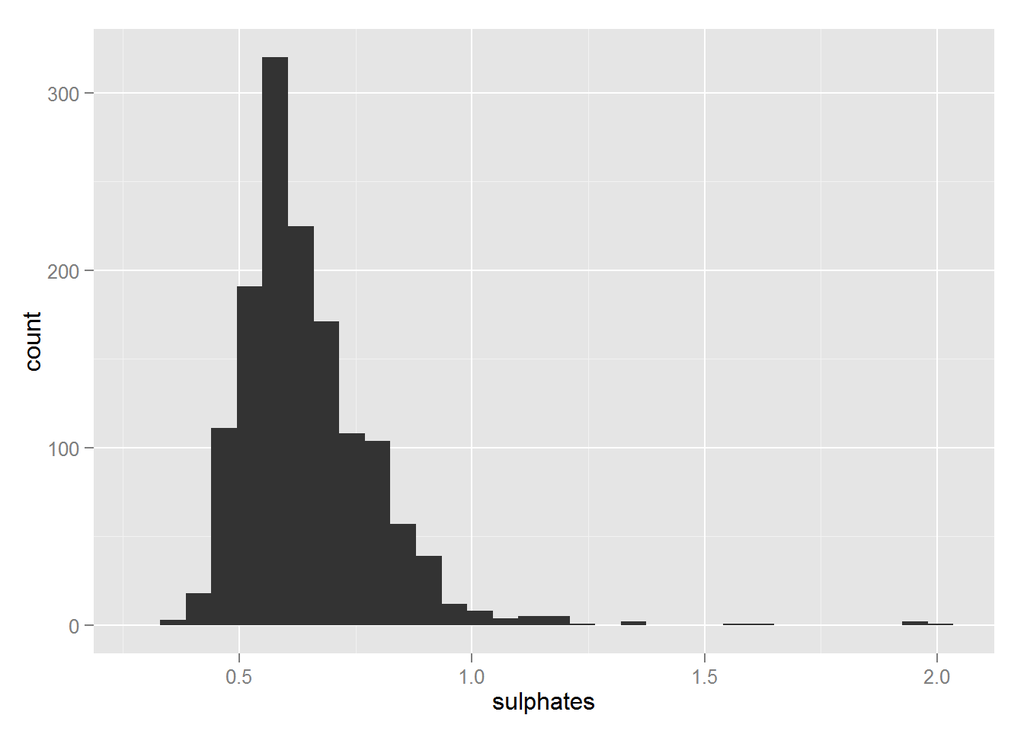

The shape of distribution reminds me that maybe I can change the x scale to log scale. But before doing that, I want to cut the outliers with values larger than 1.5.

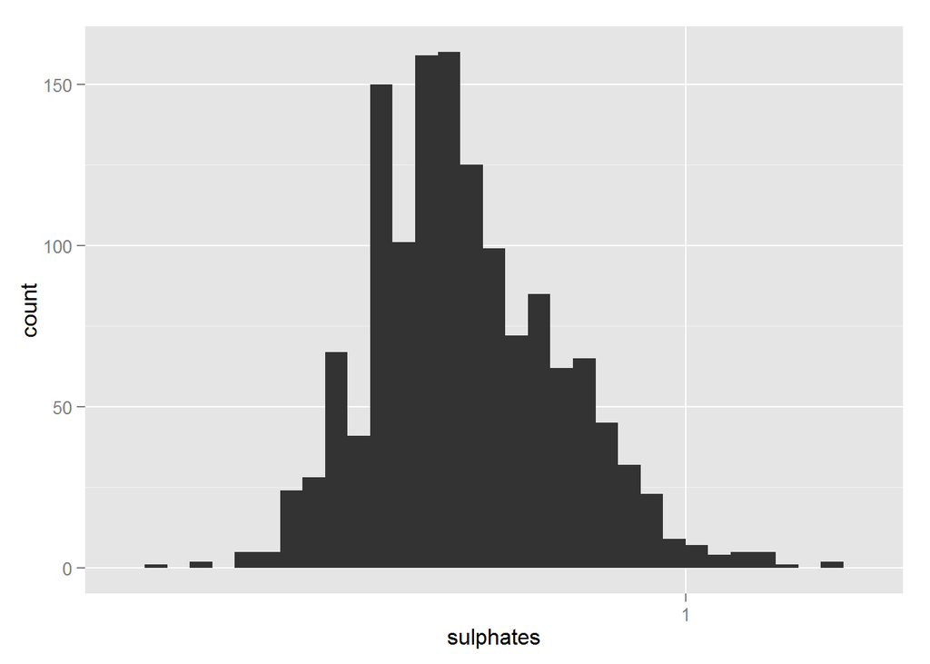

Yes. It looks like another normal distribution.

Check the distribution of alcohol.

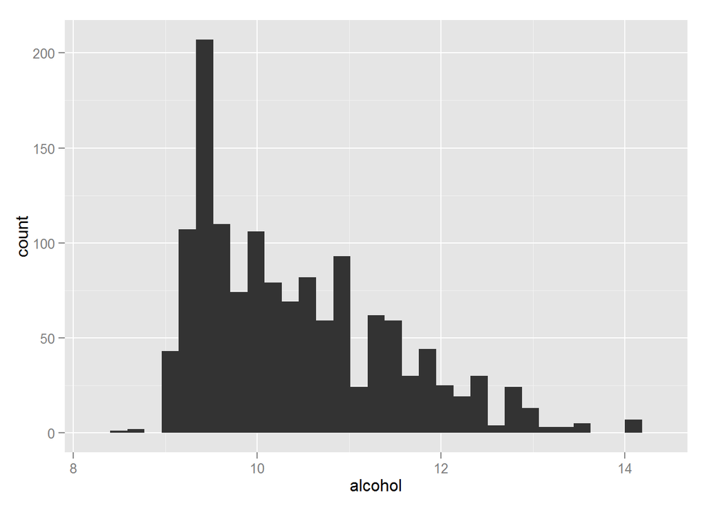

It looks like a skew distribution. All samples have an alcohol value larger than 8 but smaller than 15. That’s a typical alcohol range for red wine.

After cutting the outliers as I did above, let’s now count how many samples left.

```
## 'data.frame':    1384 obs. of  12 variables:
##  $ fixed.acidity       : num  7.4 7.8 7.8 11.2 7.4 7.4 7.9 7.3 7.8 6.7 ...
##  $ volatile.acidity    : num  0.7 0.88 0.76 0.28 0.7 0.66 0.6 0.65 0.58 0.58 ...
##  $ citric.acid         : num  0 0 0.04 0.56 0 0 0.06 0 0.02 0.08 ...
##  $ residual.sugar      : num  1.9 2.6 2.3 1.9 1.9 1.8 1.6 1.2 2 1.8 ...
##  $ chlorides           : num  0.076 0.098 0.092 0.075 0.076 0.075 0.069 0.065 0.073 0.097 ...
##  $ free.sulfur.dioxide : num  11 25 15 17 11 13 15 15 9 15 ...
##  $ total.sulfur.dioxide: num  34 67 54 60 34 40 59 21 18 65 ...
##  $ density             : num  0.998 0.997 0.997 0.998 0.998 ...
##  $ pH                  : num  3.51 3.2 3.26 3.16 3.51 3.51 3.3 3.39 3.36 3.28 ...
##  $ sulphates           : num  0.56 0.68 0.65 0.58 0.56 0.56 0.46 0.47 0.57 0.54 ...
##  $ alcohol             : num  9.4 9.8 9.8 9.8 9.4 9.4 9.4 10 9.5 9.2 ...
##  $ quality             : int  5 5 5 6 5 5 5 7 7 5 ...
```

# Univariate Analysis

### What is the structure of your dataset?

Before cutting the outliers, there are 1599 red wine samples in the dataset with 12 features (“fixed.acidity”, “volatile.acidity”, “citric.acid”, “residual.sugar”, “chlorides”, “free.sulfur.dioxide”, “total.sulfur.dioxide”, “density”, “pH”, “sulphates”, “alcohol”, “quality”). I haven’t created any new feature but I may do so when exploring deeper. After cutting the outliers, there are 1384 samples left.

### What is/are the main feature(s) of interest in your dataset?

The main feature of interest in the data set is quality. This feature may be determined by or have a correlation to the combination of other features, although it’s not direct to see which are those features. That’s what I want to explore later.

### What other features in the dataset do you think will help support your investigation into your feature(s) of interest?

All the other features may conbribute to the quality, althogh I think density may not contribute as much as alcohol. Citric acid may also be important in the determination of quality, but this guess has be verified in the deeper exploration.

### Did you create any new variables from existing variables in the dataset?

I have not created any new variables. If the exploration needs, I may want to create new variables later.

### Of the features you investigated, were there any unusual distributions? Did you perform any operations on the data to tidy, adjust, or change the form of the data? If so, why did you do this?

Most of the features are of normal or skew distribution. The citric acid distribution is kind of unusual. It has a very big bar at 0. And the most of the rest part pretty random.

I did delete the first column since “X” is just the entry id not one feature.

I also deltete the outliers to suppress noise so that in the later bivariate and mulitvariate sections it would be easier to show the correlation.

# Bivariate Plots Section

```
##                      fixed.acidity volatile.acidity citric.acid
## fixed.acidity            1.0000000      -0.26941133  0.69490026
## volatile.acidity        -0.2694113       1.00000000 -0.58000628
## citric.acid              0.6949003      -0.58000628  1.00000000
## residual.sugar           0.2509679       0.04462505  0.16496808
## chlorides                0.2408605       0.09960579  0.12708602
## free.sulfur.dioxide     -0.1551245      -0.01110341 -0.06377720
## total.sulfur.dioxide    -0.1015384       0.10531130  0.01811361
## density                  0.6775155       0.02125698  0.37081002
## pH                      -0.7136988       0.23470978 -0.52746430
## sulphates                0.2037277      -0.32681116  0.27644016
## alcohol                 -0.1162373      -0.20336675  0.08581222
## quality                  0.1234450      -0.38241202  0.23097174
##                      residual.sugar     chlorides free.sulfur.dioxide
## fixed.acidity           0.250967863  0.2408605405       -0.1551244784
## volatile.acidity        0.044625047  0.0996057872       -0.0111034125
## citric.acid             0.164968084  0.1270860242       -0.0637771978
## residual.sugar          1.000000000  0.2883018143        0.0537831285
## chlorides               0.288301814  1.0000000000        0.0008604985
## free.sulfur.dioxide     0.053783129  0.0008604985        1.0000000000
## total.sulfur.dioxide    0.133749262  0.1329606615        0.6515517687
## density                 0.414195928  0.4236410042       -0.0631466930
## pH                     -0.097670862 -0.2304238570        0.1171438673
## sulphates               0.039068580 -0.0345170888        0.0707099034
## alcohol                 0.047341444 -0.2845758116       -0.0224858913
## quality                -0.004640387 -0.1722303667       -0.0283025344
##                      total.sulfur.dioxide     density          pH
## fixed.acidity                 -0.10153842  0.67751549 -0.71369876
## volatile.acidity               0.10531130  0.02125698  0.23470978
## citric.acid                    0.01811361  0.37081002 -0.52746430
## residual.sugar                 0.13374926  0.41419593 -0.09767086
## chlorides                      0.13296066  0.42364100 -0.23042386
## free.sulfur.dioxide            0.65155177 -0.06314669  0.11714387
## total.sulfur.dioxide           1.00000000  0.07364386 -0.01668799
## density                        0.07364386  1.00000000 -0.34277839
## pH                            -0.01668799 -0.34277839  1.00000000
## sulphates                     -0.04940559  0.11812175 -0.04008692
## alcohol                       -0.21103195 -0.56355851  0.21659012
## quality                       -0.21055522 -0.20266170 -0.05724466
##                        sulphates     alcohol      quality
## fixed.acidity         0.20372775 -0.11623732  0.123444965
## volatile.acidity     -0.32681116 -0.20336675 -0.382412015
## citric.acid           0.27644016  0.08581222  0.230971739
## residual.sugar        0.03906858  0.04734144 -0.004640387
## chlorides            -0.03451709 -0.28457581 -0.172230367
## free.sulfur.dioxide   0.07070990 -0.02248589 -0.028302534
## total.sulfur.dioxide -0.04940559 -0.21103195 -0.210555215
## density               0.11812175 -0.56355851 -0.202661703
## pH                   -0.04008692  0.21659012 -0.057244655
## sulphates             1.00000000  0.22897527  0.400723709
## alcohol               0.22897527  1.00000000  0.492096533
## quality               0.40072371  0.49209653  1.000000000
```

Fixed acidity and citric acid has a strong correlation. It is possible that citric acid is one main component of fixed acidity. Fixed acidity and pH also have a strong correlation. This is easy to understand. What is interesting is that density strongly depends on fixed acidity. I did not predict that. It is possible that the components in the red wine producing fixed acidity have larger density than other components.

Free sulfur dioxide and total sulfur dioxide have very similar distribution. They also have a strong correlation. That is predictable.

Although the distributions of residual sugar and chlorites are very simlar, the correlation between them is acturally very very weak.

The feature I’m interested in is quality. It shows that the quality has a pretty large correlation with alochol (with a value of 0.49). The most possible features that quality depends on are: alcohol, sulphates, volatile acidity, citric acid, total sulfur dioxide.

I want to use the ggpair table to show the correlation between each features. But at first I want to copy the dataset and change the names to shorter ones.

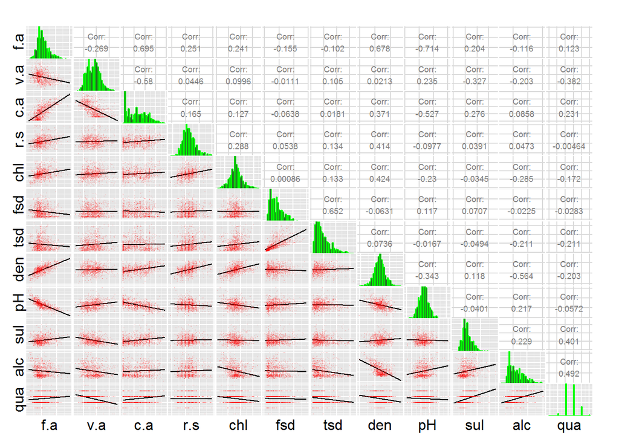

To explore deeper, let me use scatter plots involving quality and the features which have an absoulute correlation larger than 0.1 with quality: “fixed.acidity”, “volatile.acidity”, “citric.acid”, “chlorides”,“total.sulfur.dioxide”, “density”, “sulphates” and “alcohol”. I will also create a new feature called qualFact which is “factorized” quality, so that I can draw boxplots and use quality as category.

In the following plots, I would like to use “geom_jitter” instead of “geom_point” to separate the points.

Check scatter plot of quality VS fixed acidty and the boxplot of fixed acidity.

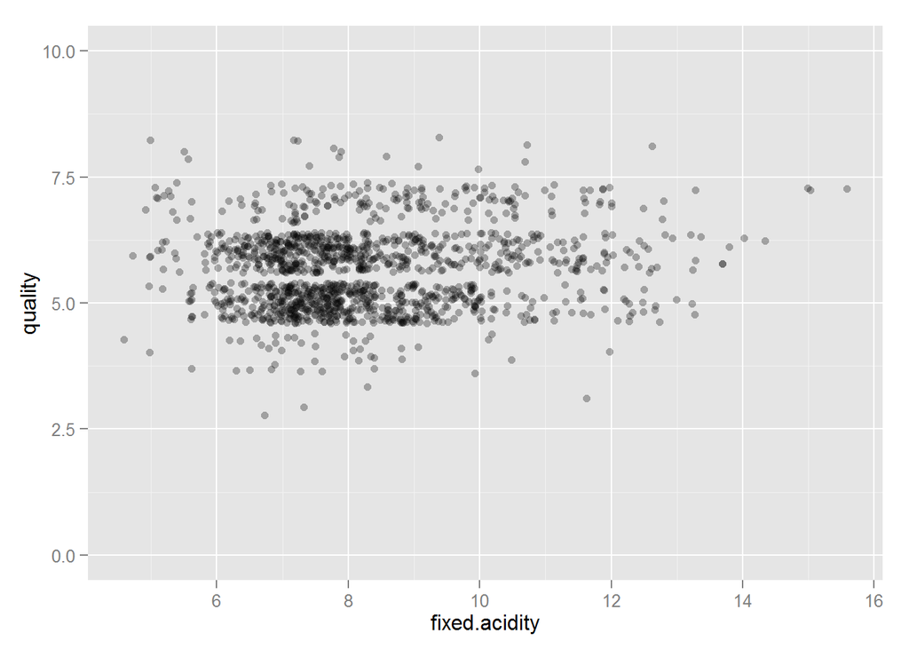

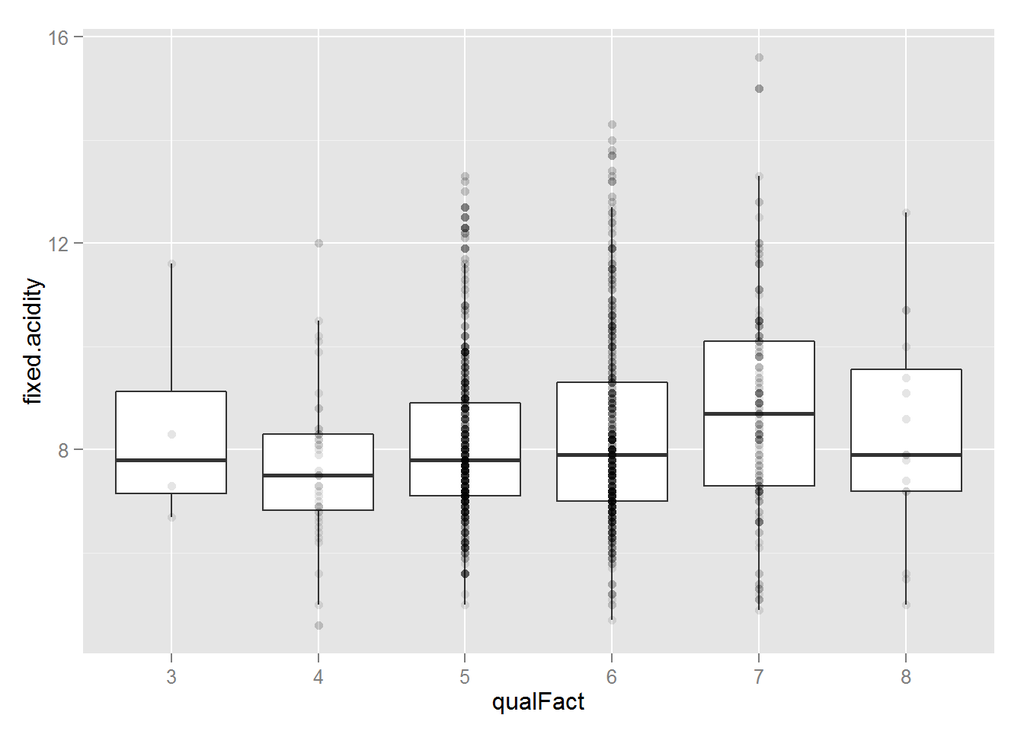

From the scatter plot we can not see clear correlation between fixed acidity and quality. But we do see that for most of wine having a quality 5 or 6, the fixed acidity is 6 to 9. The trend of medan and average from the boxplot is not very clear. The correlation between quality and fixed acidity is weak.

Check plot of quality VS volatile acidity and the boxplot of volatile acidity.

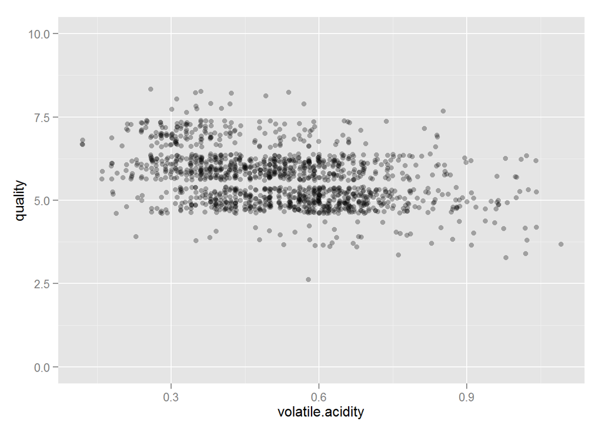

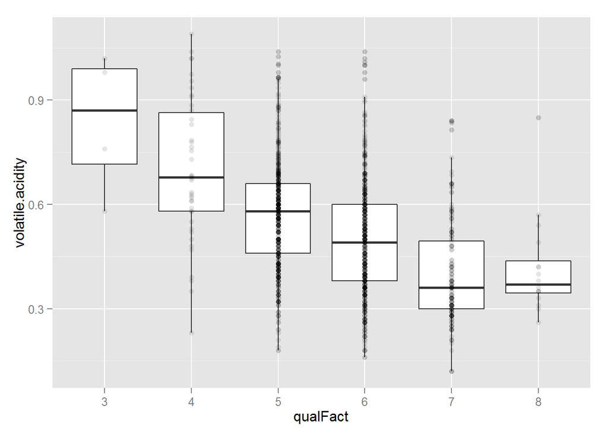

The scatter plot shows more obvious correlation than the previous one for fixed acidity. We can see there is a trend that when volatile acidity increases, quality decreases. The trends of average and median from the boxplot are even more obvious to show such a correlation.

Check scatter plot of quality VS citric acid and boxplot of citric acid.

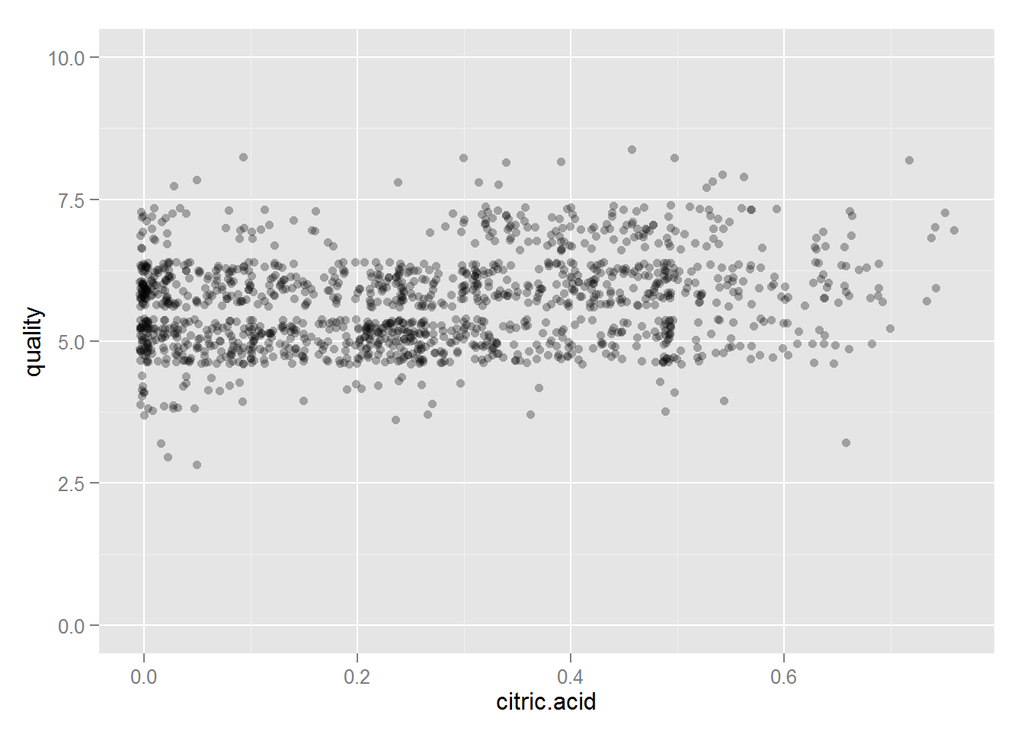

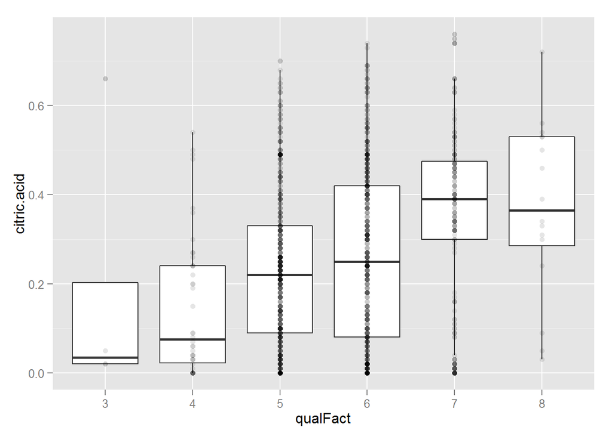

The citric acid is almost distributed uniformly on each quality in the scatter plot. There is no clear correlaiton from the scatter plot. But from the boxplot, the trends of median and average are pretty clear. When citric acid increases, quality increases.

Check scatter plot of quality VS chlorides and boxplot of chlorides.

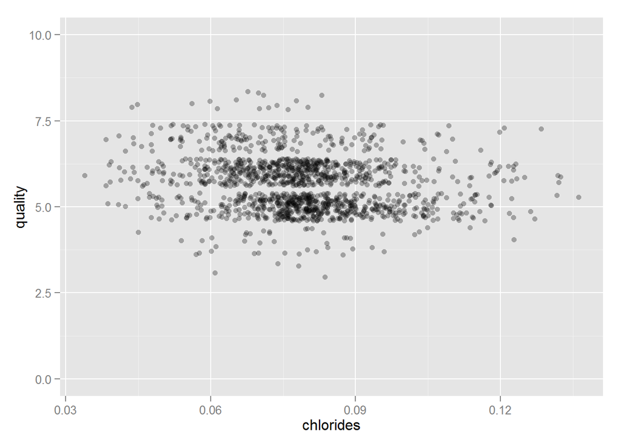

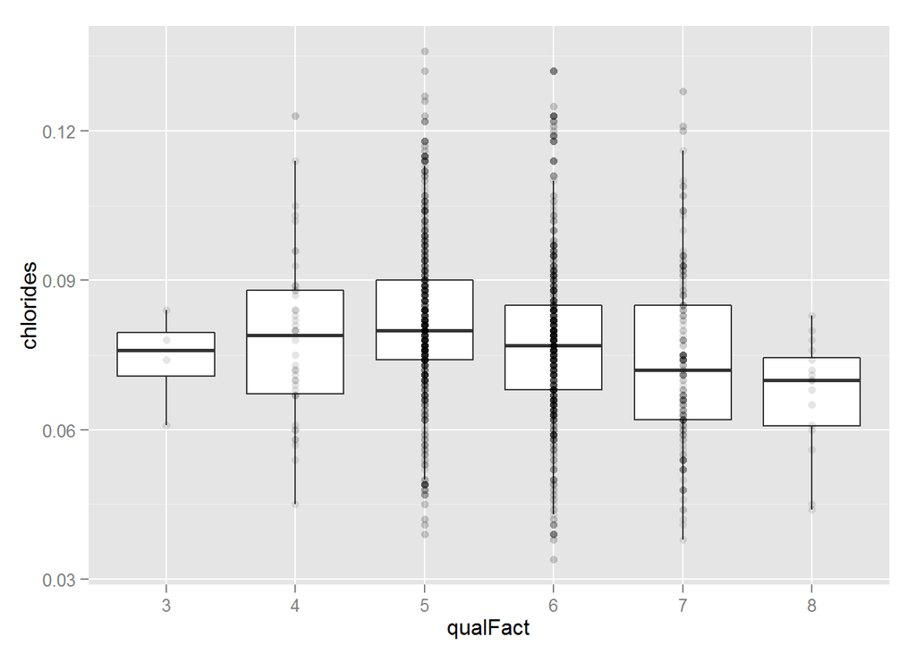

The correlation on this plot is also not very clear. But if we look at the scatter plot, it shows vaguely that when chlorides decreases, quality increases. The trends of average and median both show that when chlorides decreases, quality increases. But the correlation is not very strong.

Check scatter plot of quality VS total sulfur dioxide and the boxplot of total sulfur dioxide.

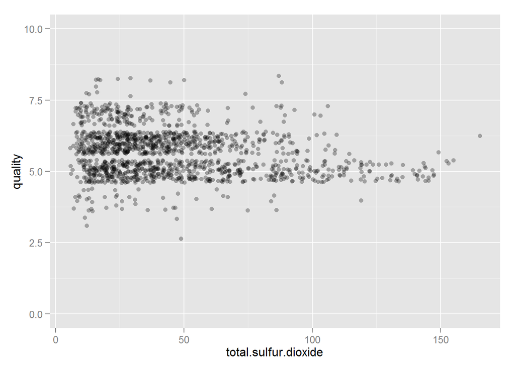

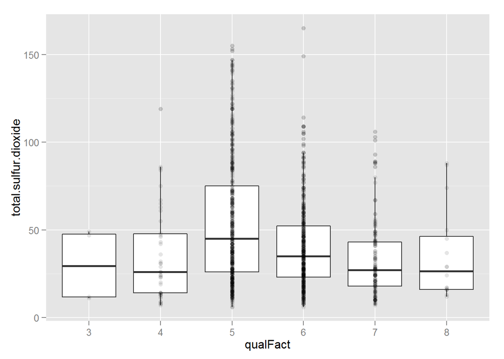

The correlaiton is not clear on scatter polt. The trends of average and median show that the relation between tota sulfur dioxide and quality is not linear. So adding total sulfur dioxide into the linear model to predict quality may not help.